# IntroR: Final Report Analysis

Ryuki Matsuura

2024/11/27

## 1. Introduction

In this notebook, I examine the relationship between utterance fluency (UF) measures and L2 speaking anxiety, addressing the following three research questions (RQs):

- RQ1: To what extent are speed fluency measures associated with cognitive, somatic, and behavioral speaking anxiety?
- RQ2: To what extent are breakdown fluency measures associated with cognitive, somatic, and behavioral speaking anxiety?
- RQ3: To what extent are repair fluency measures associated with cognitive, somatic, and behavioral speaking anxiety?

In the following sections, I preprocess data, conduct preliminary analyses, and construct regression models.

The following code block loads R packages required for analyses.

```r
pacman::p_load(
  tidyverse, here, skimr, psych,
  PerformanceAnalytics, sjPlot, performance
)
```

## 2. Data Preprocess

This section tidies data. First of all, the following code block loads data of UF measures.

```r
df_uf_raw <- read.csv(here("data", "processed", "uf_measures.csv"))
```

The current analysis focuses on the UF measures shown in Table 1.

Table 1. UF Dimension and Corresponding Measures

| UF Dimension | Measure |
| --- | --- |
| Speed Fluency (SF) | Articulation Rate (AR) |
| Breakdown Fluency (BDF) | Mid-Clause Pause Ratio (MCPR) |
|  | End-Clause Pause Ratio (ECPR) |
|  | Mid-Clause Pause Duration (MCPD) |
|  | End-Clause Pause Duration (ECPD) |
| Repair Fluency (RF) | Disfluency Ratio |

Thus, the following code block selects target measures. The code block also renames the columns `filename` and `dysfluency_ratio` to `participant_id` and `disfluency_ratio`, respectively.

```r
df_uf_raw %>%
  select(
    filename,
    articulation_rate,
    mid_clause_pause_ratio,
    end_clause_pause_ratio,
    mid_clause_p.dur,
    end_clause_p.dur,
    dysfluency_ratio
  ) %>%
  rename(
    participant_id = filename,
    disfluency_ratio = dysfluency_ratio
  ) -> df_uf_tidy

df_uf_tidy
```

| participant_id | articulation_rate | mid_clause_pause_ratio | end_clause_pause_ratio | mid_clause_p.dur | end_clause_p.dur | disfluency_ratio |
| --- | --- | --- | --- | --- | --- | --- |
| E001 | 4.899343 | 0.07954545 | 0.07386364 | 1.2529464 | 1.1308654 | 0.02840909 |
| E002 | 2.700844 | 0.21839080 | 0.08620690 | 0.7579490 | 0.9413917 | 0.05172414 |
| E003 | 4.767936 | 0.12777778 | 0.06111111 | 0.4410000 | 0.4856023 | 0.01666667 |
| E004 | 3.463897 | 0.23333333 | 0.05833333 | 1.0979598 | 1.1858304 | 0.03333333 |
| E005 | 3.888609 | 0.15920398 | 0.06467662 | 0.7388965 | 0.8155433 | 0.02985075 |
| E006 | 3.325243 | 0.29166667 | 0.06060606 | 0.5455414 | 0.6813672 | 0.14393939 |
| E007 | 4.362804 | 0.14754098 | 0.04644809 | 0.6441586 | 0.7342059 | 0.06830601 |
| E008 | 3.678672 | 0.20805369 | 0.08053691 | 0.5716633 | 0.6425599 | 0.08724832 |
| P001 | 3.718758 | 0.22093023 | 0.06104651 | 0.5879227 | 0.5905089 | 0.11337209 |
| P002 | 3.334997 | 0.20869565 | 0.06086957 | 0.9331345 | 1.1048542 | 0.10144928 |

Next, the following code block loads data of post questionnaire about anxiety and linguistic background.

```r
df_questionnaire_raw <- read.csv(
  here("data", "raw", "post_questionnaire.csv")
)
```

The following code block selects columns related to participant ID, anxiety, L2 English proficiency, and other backgrounds and renames them.

```r
df_questionnaire_raw %>%
  select(
    参加者IDを入力してください.半角..,
    英語を話すとき.私は言葉を間違えてしまうのではとしばしば心配になる.,
    英語を話すとき.私は自分の話し方が他人より劣っているのではとしばしば心配になる.,
    英語を話し始めるとすぐに.私は自分自身のことを表現できないのではと心配になり始める.,
    英語を話すとき.私はドキドキすることがよくある.,
    英語を話すとき.私は緊張でびくびくすることがよくある.,
    英語を話すとき.私はよく汗をかいたり.発汗する.,
    英語スピーキングの練習をするとき.私はしばしば.すぐに投げ出してしまう.,
    私は英語スピーキングの練習の手を抜くことが多い.,
    私は普段.極力英語を話さないようにしている.,
    お持ちでしたら.英検のスコアを記入してください.,
    お持ちでしたら.IELTS..Overall..のスコアを記入してください.,
    お持ちでしたら.TOEFL.iBT.のスコアを記入してください.,
    お持ちでしたら.TOEIC.のスコアを記入してください.,
    性別,
    年齢
  ) %>%
  rename(
    participant_id = 参加者IDを入力してください.半角..,
    cognitive_anxiety_1 = 英語を話すとき.私は言葉を間違えてしまうのではとしばしば心配になる.,
    cognitive_anxiety_2 = 英語を話すとき.私は自分の話し方が他人より劣っているのではとしばしば心配になる.,
    cognitive_anxiety_3 = 英語を話し始めるとすぐに.私は自分自身のことを表現できないのではと心配になり始める.,
    somatic_anxiety_1 = 英語を話すとき.私はドキドキすることがよくある.,
    somatic_anxiety_2 = 英語を話すとき.私は緊張でびくびくすることがよくある.,
    somatic_anxiety_3 = 英語を話すとき.私はよく汗をかいたり.発汗する.,
    behavioral_anxiety_1 = 英語スピーキングの練習をするとき.私はしばしば.すぐに投げ出してしまう.,
    behavioral_anxiety_2 = 私は英語スピーキングの練習の手を抜くことが多い.,
    behavioral_anxiety_3 = 私は普段.極力英語を話さないようにしている.,
    IELTS = お持ちでしたら.IELTS..Overall..のスコアを記入してください.,
    TOEFL_IBT = お持ちでしたら.TOEFL.iBT.のスコアを記入してください.,
    TOEIC = お持ちでしたら.TOEIC.のスコアを記入してください.,
    eiken = お持ちでしたら.英検のスコアを記入してください.,
    sex = 性別,
    age = 年齢
  ) %>%
  mutate(
    sex = str_replace_all(sex, "男性", "male"),
    sex = str_replace_all(sex, "女性", "female"),
    eiken = str_replace_all(eiken, "準1級", "1.5"),
    eiken = str_replace_all(eiken, "準１級", "1.5"),
    eiken = str_replace_all(eiken, "2級", "2"),
    eiken = str_replace_all(eiken, "1級", "1"),
    eiken = str_replace_all(eiken, "英検4級", "4"),
    eiken = as.numeric(eiken)
  ) -> df_questionnaire_tidy

df_questionnaire_tidy
```

| participant_id | cognitive_anxiety_1 | cognitive_anxiety_2 | cognitive_anxiety_3 | somatic_anxiety_1 | somatic_anxiety_2 | somatic_anxiety_3 | behavioral_anxiety_1 | behavioral_anxiety_2 | behavioral_anxiety_3 | eiken | IELTS | TOEFL_IBT | TOEIC | sex | age |
| --- | --- | --- | --- | --- | --- | --- | --- | --- | --- | --- | --- | --- | --- | --- | --- |
| P001 | 5 | 4 | 5 | 5 | 5 | 4 | 2 | 2 | 4 | 1.5 | NA | 100 | NA | female | 23 |
| P002 | 2 | 4 | 2 | 2 | 1 | 4 | 2 | 2 | 1 | NA | NA | NA | 930 | female | 26 |
| E001 | 2 | 2 | 1 | 1 | 1 | 1 | 1 | 1 | 1 | 1.5 | NA | NA | NA | female | 38 |
| E002 | 4 | 1 | 1 | 1 | 1 | 1 | 1 | 1 | 1 | NA | NA | 105 | NA | male | 26 |
| E003 | 5 | 4 | 2 | 4 | 5 | 4 | 5 | 5 | 3 | NA | 7 | NA | NA | male | 29 |
| E004 | 5 | 5 | 5 | 5 | 5 | 4 | 2 | 3 | 2 | 2.0 | NA | NA | 745 | female | 31 |
| E005 | 4 | 5 | 4 | 4 | 2 | 2 | 2 | 2 | 2 | NA | NA | 105 | 900 | female | 29 |
| E006 | 3 | 4 | 5 | 3 | 3 | 2 | 3 | 4 | 3 | NA | NA | 90 | NA | male | 37 |
| E007 | 4 | 4 | 4 | 2 | 2 | 1 | 3 | 4 | 1 | 1.0 | 7 | 100 | NA | male | 20 |
| E008 | 2 | 4 | 2 | 2 | 3 | 2 | 4 | 4 | 2 | 4.0 | NA | 101 | 960 | male | 29 |

## 3. Preliminary Analysis

### 3.1. Participant Background

The following code block calculates the descriptive statistics of participants’ age.

```r
df_questionnaire_tidy %>%
  select(age) %>%
  skim()
```

Data summary

| Name | Piped data |
| --- | --- |
| Number of rows | 10 |
| Number of columns | 1 |
| _______________________ |  |
| Column type frequency: |  |
| numeric | 1 |
| ________________________ |  |
| Group variables | None |

**Variable type: numeric**

| skim_variable | n_missing | complete_rate | mean | sd | p0 | p25 | p50 | p75 | p100 | hist |
| --- | --- | --- | --- | --- | --- | --- | --- | --- | --- | --- |
| age | 0 | 1 | 28.8 | 5.61 | 20 | 26 | 29 | 30.5 | 38 | ▅▅▇▂▅ |

The result showed that participants’ age was ranged $[20, 38]$, and their mean and SD were $28.8$ and $5.613$.

The following code block counts sex of participants.

```r
df_questionnaire_tidy %>%
  group_by(sex) %>%
  summarize(N = n())
```

| sex | N |
| --- | --- |
| female | 5 |
| male | 5 |

The result indicated that there were equal number of male and female participants.

### 3.2. Proficiency Levels

The following code block converts L2 English assessment scores to CEFR.

```r
cefr_levels = c("A1", "A2", "B1", "B2", "C1", "C2")

df_questionnaire_tidy %>%
  select(participant_id, TOEFL_IBT, IELTS, TOEIC, eiken) %>%
  mutate(
    TOEFL_IBT = case_when(
      TOEFL_IBT >= 114 ~ "C2",
      TOEFL_IBT >= 95 ~ "C1",
      TOEFL_IBT >= 72 ~ "B2"
    ),
    IELTS = case_when(
      IELTS >= 7 ~ "C1"
    ),
    TOEIC = case_when(
      TOEIC >= 945 ~ "C1",
      TOEIC >= 785 ~ "B1",
      TOEIC >= 550 ~ "B2"
    ),
    eiken = case_when(
      eiken >= 3 ~ "A1",
      eiken >= 2 ~ "B1",
      eiken >= 1.5 ~ "B2",
      eiken >= 1 ~ "C1"
    )
  ) %>%
  mutate(
    TOEFL_IBT = factor(TOEFL_IBT, levels = cefr_levels, order = T),
    IELTS = factor(IELTS, levels = cefr_levels, order = T),
    TOEIC = factor(TOEIC, levels = cefr_levels, order = T),
    eiken = factor(eiken, levels = cefr_levels, order = T)
  ) %>%
  replace_na(list(
    TOEFL_IBT = "A1",
    IELTS = "A1",
    TOEIC = "A1",
    eiken = "A1"
  )) %>%
  group_by(participant_id) %>%
  summarize(CEFR = max(TOEFL_IBT, IELTS, TOEIC, eiken)) %>%
  group_by(CEFR) %>%
  summarize(N = n())
```

| CEFR | N |
| --- | --- |
| B1 | 1 |
| B2 | 3 |
| C1 | 6 |

The result suggested that most participants were advanced-level L2 English learners ($N=6$), while other four participants were intermediate-level English learners.

### 3.3. UF Measures

The following code block calculates the descriptive statistics of UF measures.

```r
df_uf_tidy %>%
  select(-c(participant_id)) %>%
  skim()
```

Data summary

| Name | Piped data |
| --- | --- |
| Number of rows | 10 |
| Number of columns | 6 |
| _______________________ |  |
| Column type frequency: |  |
| numeric | 6 |
| ________________________ |  |
| Group variables | None |

**Variable type: numeric**

| skim_variable | n_missing | complete_rate | mean | sd | p0 | p25 | p50 | p75 | p100 | hist |
| --- | --- | --- | --- | --- | --- | --- | --- | --- | --- | --- |
| articulation_rate | 0 | 1 | 3.8141 | 0.6874 | 2.7008 | 3.3672 | 3.6987 | 4.2443 | 4.8993 | ▂▇▇▂▅ |
| mid_clause_pause_ratio | 0 | 1 | 0.1895 | 0.0610 | 0.0795 | 0.1505 | 0.2084 | 0.2203 | 0.2917 | ▂▅▁▇▂ |
| end_clause_pause_ratio | 0 | 1 | 0.0654 | 0.0117 | 0.0464 | 0.0607 | 0.0611 | 0.0716 | 0.0862 | ▂▇▂▂▃ |
| mid_clause_p.dur | 0 | 1 | 0.7571 | 0.2612 | 0.4410 | 0.5757 | 0.6915 | 0.8893 | 1.2529 | ▇▆▁▂▃ |
| end_clause_p.dur | 0 | 1 | 0.8313 | 0.2467 | 0.4856 | 0.6523 | 0.7749 | 1.0640 | 1.1858 | ▅▇▂▂▇ |
| disfluency_ratio | 0 | 1 | 0.0674 | 0.0427 | 0.0167 | 0.0307 | 0.0600 | 0.0979 | 0.1439 | ▇▂▃▃▂ |

### 3.4. Speaking Anxiety

The following code blocks calculate the reliability of anxiety questionnaire answers in terms of Cronbach’s $\alpha$.

#### *3.4.1. Reliability of Cognitive Anxiety*

```r
df_questionnaire_tidy %>%
  select(
    cognitive_anxiety_1,
    cognitive_anxiety_2,
    cognitive_anxiety_3
  ) %>%
  alpha()
```

```
##
## Reliability analysis
## Call: alpha(x = .)
##
##   raw_alpha std.alpha G6(smc) average_r S/N  ase mean  sd median_r
##       0.75      0.74    0.73      0.49 2.9 0.13  3.5 1.1      0.5
##
##     95% confidence boundaries
##          lower alpha upper
## Feldt     0.26  0.75  0.93
## Duhachek  0.49  0.75  1.00
##
##  Reliability if an item is dropped:
##                     raw_alpha std.alpha G6(smc) average_r  S/N alpha se var.r
## cognitive_anxiety_1      0.81      0.83    0.71      0.71 4.89     0.11    NA
## cognitive_anxiety_2      0.65      0.66    0.50      0.50 1.97     0.21    NA
## cognitive_anxiety_3      0.42      0.42    0.27      0.27 0.73     0.37    NA
##                     med.r
## cognitive_anxiety_1  0.71
## cognitive_anxiety_2  0.50
## cognitive_anxiety_3  0.27
##
##  Item statistics
##                      n raw.r std.r r.cor r.drop mean  sd
## cognitive_anxiety_1 10  0.71  0.72  0.49   0.43  3.6 1.3
## cognitive_anxiety_2 10  0.81  0.81  0.72   0.60  3.7 1.3
## cognitive_anxiety_3 10  0.92  0.90  0.87   0.76  3.1 1.7
##
## Non missing response frequency for each item
##                       1   2   3   4   5 miss
## cognitive_anxiety_1 0.0 0.3 0.1 0.3 0.3    0
## cognitive_anxiety_2 0.1 0.1 0.0 0.6 0.2    0
## cognitive_anxiety_3 0.2 0.3 0.0 0.2 0.3    0
```

The Cornbach’s $\alpha$ of cognitive anxiety questionnaires was $.747$, indicating an acceptable internal consistency

#### *3.4.2. Reliability of Somatic Anxiety*

```r
df_questionnaire_tidy %>%
  select(
    somatic_anxiety_1,
    somatic_anxiety_2,
    somatic_anxiety_3
  ) %>%
  alpha()
```

```
##
## Reliability analysis
## Call: alpha(x = .)
##
##   raw_alpha std.alpha G6(smc) average_r S/N   ase mean  sd median_r
##        0.9       0.9    0.87      0.75 9.2 0.053  2.7 1.4     0.73
##
##     95% confidence boundaries
##          lower alpha upper
## Feldt     0.71   0.9  0.97
## Duhachek  0.80   0.9  1.00
##
##  Reliability if an item is dropped:
##                   raw_alpha std.alpha G6(smc) average_r  S/N alpha se var.r
## somatic_anxiety_1      0.80      0.81    0.68      0.68  4.3     0.12    NA
## somatic_anxiety_2      0.84      0.84    0.73      0.73  5.3     0.10    NA
## somatic_anxiety_3      0.92      0.92    0.86      0.86 11.9     0.05    NA
##                   med.r
## somatic_anxiety_1  0.68
## somatic_anxiety_2  0.73
## somatic_anxiety_3  0.86
##
##  Item statistics
##                    n raw.r std.r r.cor r.drop mean  sd
## somatic_anxiety_1 10  0.94  0.94  0.92   0.87  2.9 1.5
## somatic_anxiety_2 10  0.94  0.92  0.89   0.83  2.8 1.7
## somatic_anxiety_3 10  0.86  0.88  0.76   0.73  2.5 1.4
##
## Non missing response frequency for each item
##                     1   2   3   4   5 miss
## somatic_anxiety_1 0.2 0.3 0.1 0.2 0.2    0
## somatic_anxiety_2 0.3 0.2 0.2 0.0 0.3    0
## somatic_anxiety_3 0.3 0.3 0.0 0.4 0.0    0
```

The Cornbach’s $\alpha$ of somatic anxiety questionnaires was $.900$, indicating a excellent internal consistency.

#### 3.4.3. Behavioral Anxiety

```r
df_questionnaire_tidy %>%
  select(
    behavioral_anxiety_1,
    behavioral_anxiety_2,
    behavioral_anxiety_3
  ) %>%
  alpha()
```

```
##
## Reliability analysis
## Call: alpha(x = .)
##
##   raw_alpha std.alpha G6(smc) average_r S/N ase mean  sd median_r
##       0.81       0.8    0.84      0.58 4.1 0.1  2.4 1.1     0.42
##
##     95% confidence boundaries
##          lower alpha upper
## Feldt     0.46  0.81  0.95
## Duhachek  0.61  0.81  1.01
##
##  Reliability if an item is dropped:
##                      raw_alpha std.alpha G6(smc) average_r  S/N alpha se var.r
## behavioral_anxiety_1      0.53      0.55    0.38      0.38  1.2    0.283    NA
## behavioral_anxiety_2      0.58      0.59    0.42      0.42  1.4    0.260    NA
## behavioral_anxiety_3      0.97      0.97    0.94      0.94 30.8    0.021    NA
##                      med.r
## behavioral_anxiety_1  0.38
## behavioral_anxiety_2  0.42
## behavioral_anxiety_3  0.94
##
##  Item statistics
##                       n raw.r std.r r.cor r.drop mean  sd
## behavioral_anxiety_1 10  0.94  0.93  0.96   0.86  2.5 1.3
## behavioral_anxiety_2 10  0.93  0.91  0.95   0.81  2.8 1.4
## behavioral_anxiety_3 10  0.66  0.70  0.42   0.40  2.0 1.1
##
## Non missing response frequency for each item
##                        1   2   3   4   5 miss
## behavioral_anxiety_1 0.2 0.4 0.2 0.1 0.1    0
## behavioral_anxiety_2 0.2 0.3 0.1 0.3 0.1    0
## behavioral_anxiety_3 0.4 0.3 0.2 0.1 0.0    0
```

### 3.5. Correlations

This subsection conducts correlation analyses between UF measures and speaking anxiety. Before the analyses, the following code block calculates three anxiety scores by summing items and joins the two dataframes.

```r
df_questionnaire_tidy %>%
  group_by(participant_id) %>%
  summarize(
    cognitive_anxiety = sum(
      cognitive_anxiety_1, cognitive_anxiety_2, cognitive_anxiety_3
    ),
    somatic_anxiety = sum(
      somatic_anxiety_1, somatic_anxiety_2, somatic_anxiety_3
    ),
    behavioral_anxiety = sum(
      behavioral_anxiety_1, behavioral_anxiety_2, behavioral_anxiety_3
    )
  ) %>%
  inner_join(
    df_uf_tidy, by = "participant_id"
  ) -> df_uf_anxiety

df_uf_anxiety
```

| participant_id | cognitive_anxiety | somatic_anxiety | behavioral_anxiety | articulation_rate | mid_clause_pause_ratio | end_clause_pause_ratio | mid_clause_p.dur | end_clause_p.dur | disfluency_ratio |
| --- | --- | --- | --- | --- | --- | --- | --- | --- | --- |
| E001 | 5 | 3 | 3 | 4.899343 | 0.07954545 | 0.07386364 | 1.2529464 | 1.1308654 | 0.02840909 |
| E002 | 6 | 3 | 3 | 2.700844 | 0.21839080 | 0.08620690 | 0.7579490 | 0.9413917 | 0.05172414 |
| E003 | 11 | 13 | 13 | 4.767936 | 0.12777778 | 0.06111111 | 0.4410000 | 0.4856023 | 0.01666667 |
| E004 | 15 | 14 | 7 | 3.463897 | 0.23333333 | 0.05833333 | 1.0979598 | 1.1858304 | 0.03333333 |
| E005 | 13 | 8 | 6 | 3.888609 | 0.15920398 | 0.06467662 | 0.7388965 | 0.8155433 | 0.02985075 |
| E006 | 12 | 8 | 10 | 3.325243 | 0.29166667 | 0.06060606 | 0.5455414 | 0.6813672 | 0.14393939 |
| E007 | 12 | 5 | 8 | 4.362804 | 0.14754098 | 0.04644809 | 0.6441586 | 0.7342059 | 0.06830601 |
| E008 | 8 | 7 | 10 | 3.678672 | 0.20805369 | 0.08053691 | 0.5716633 | 0.6425599 | 0.08724832 |
| P001 | 14 | 14 | 8 | 3.718758 | 0.22093023 | 0.06104651 | 0.5879227 | 0.5905089 | 0.11337209 |
| P002 | 8 | 7 | 5 | 3.334997 | 0.20869565 | 0.06086957 | 0.9331345 | 1.1048542 | 0.10144928 |

The following code block calculates the descriptive statistics of anxiety scores.

```r
df_uf_anxiety %>%
  select(cognitive_anxiety, somatic_anxiety, behavioral_anxiety) %>%
  skim()
```

Data summary

| Name | Piped data |
| --- | --- |
| Number of rows | 10 |
| Number of columns | 3 |
| _______________________ |  |
| Column type frequency: |  |
| numeric | 3 |
| ________________________ |  |
| Group variables | None |

**Variable type: numeric**

| skim_variable | n_missing | complete_rate | mean | sd | p0 | p25 | p50 | p75 | p100 | hist |
| --- | --- | --- | --- | --- | --- | --- | --- | --- | --- | --- |
| cognitive_anxiety | 0 | 1 | 10.4 | 3.4383 | 5 | 8.00 | 11.5 | 12.75 | 15 | ▅▅▂▇▅ |
| somatic_anxiety | 0 | 1 | 8.2 | 4.1846 | 3 | 5.50 | 7.5 | 11.75 | 14 | ▇▅▅▁▇ |
| behavioral_anxiety | 0 | 1 | 7.3 | 3.1990 | 3 | 5.25 | 7.5 | 9.50 | 13 | ▇▅▅▅▂ |

The following code block saves the concatenated dataframe as a csv file.

```r
write.csv(df_uf_anxiety, here("data", "processed", "uf_anxiety.csv"))
```

#### 3.5.1. Correlations Among Anxiety Scores

The following code block generates a correlation matrix of three anxiety scores.

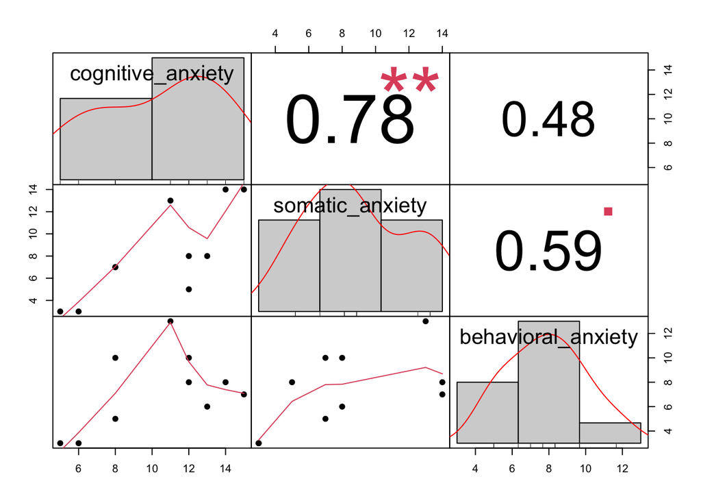

```r
df_uf_anxiety %>%
  select(
    cognitive_anxiety,
    somatic_anxiety,
    behavioral_anxiety
  ) %>%
  chart.Correlation(histogram = T, method = "pearson", pch = 19)
```

The result showed that significant strong correlation between cognitive and somatic anxiety ($r=.78$). In addition, there was slightly significant medium correlation between somatic and behavioral anxiety ($r=.59$). Meanwhile, there was small correlation between cognitive and behavioral anxiety ($r=.48$), but statistical significance was not found.

#### 3.5.2. Correlations Between UF Measures and Cognitive Anxiety

The following code block generates a correlation matrix of UF measures and cognitive anxiety.

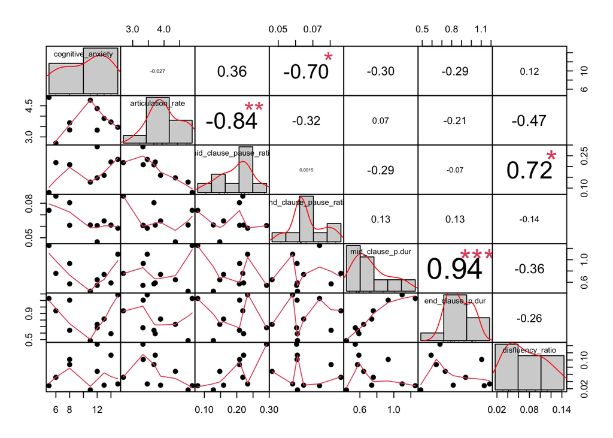

```r
df_uf_anxiety %>%
  select(-c(
    participant_id,
    somatic_anxiety,
    behavioral_anxiety
  )) %>%
  chart.Correlation(histogram = T, method = "pearson", pch = 19)
```

The result showed significant large correlation between cognitive anxiety and ECPR, suggesting that participants produced end-clause pauses more frequently when cognitive anxiety was lower.

#### 3.5.3. Correlations Between UF Measures and Somatic Anxiety

The following code block generates a correlation matrix of UF measures and somatic anxiety.

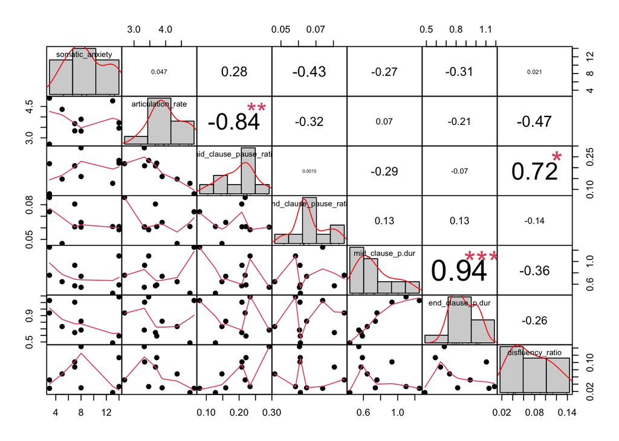

```r
df_uf_anxiety %>%
  select(-c(
    participant_id,
    cognitive_anxiety,
    behavioral_anxiety
  )) %>%
  chart.Correlation(histogram = T, method = "pearson", pch = 19)
```

The result did not show significant correlations between somatic anxiety and UF measures.

#### 3.5.4. Correlations Between UF Measures and Behavioral Anxiety

The following code block generates a correlation matrix of UF measures and behavioral anxiety.

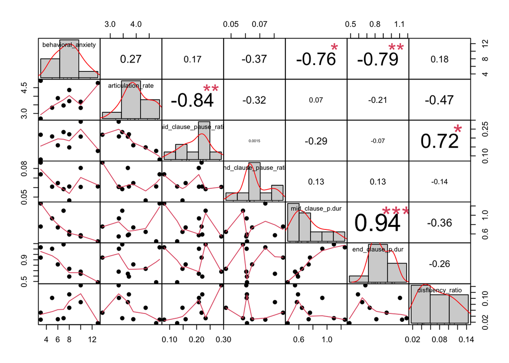

```r
df_uf_anxiety %>%
  select(-c(
    participant_id,
    cognitive_anxiety,
    somatic_anxiety
  )) %>%
  chart.Correlation(histogram = T, method = "pearson", pch = 19)
```

## 4. Regression Analyses

### 4.1. SF ~ Speaking Anxiety

The following code block constructs a regression model between AR and speaking anxiety.

```r
model_ar <- lm(
  articulation_rate ~ cognitive_anxiety + somatic_anxiety + behavioral_anxiety,
  df_uf_anxiety
)
```

The following code block shows the result.

```r
tab_model(model_ar, digits = 3)
```

|  | articulation_rate |  |  |
| --- | --- | --- | --- |
| Predictors | Estimates | CI | p |
| (Intercept) | 3.649 | 1.383 – 5.915 | **0.008** |
| cognitive anxiety | -0.036 | -0.340 – 0.267 | 0.778 |
| somatic anxiety | -0.006 | -0.276 – 0.265 | 0.962 |
| behavioral anxiety | 0.081 | -0.172 – 0.333 | 0.464 |
| Observations | 10 |  |  |
| R<sup>2</sup> / R<sup>2</sup> adjusted | 0.104 / -0.344 |  |  |

The result did not show significant relationship between three anxiety scores and AR.

To examine the reliability of the current model, the following code block conducts post-hoc analysis of regression assumptions.

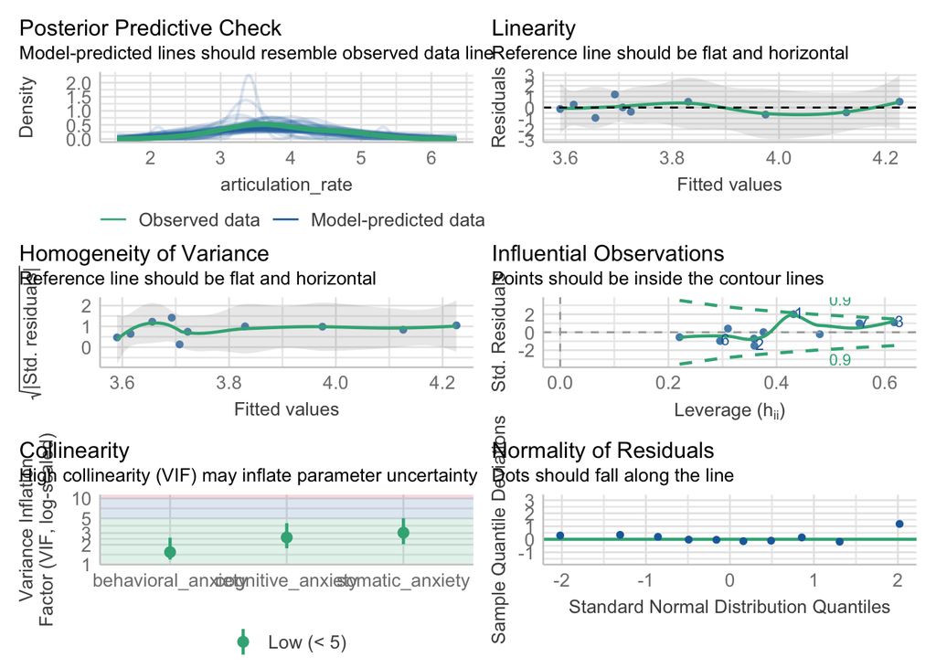

```r
check_model(model_ar)
```

The results suggested that the current model could be reliable.

### 4.2. BDF ~ Speaking Anxiety

#### 4.2.1. MCPR ~ Speaking Anxiety

The following code block constructs a regression model between MCPR and speaking anxiety.

```r
model_mcpr <- lm(
  mid_clause_pause_ratio ~ cognitive_anxiety + somatic_anxiety + behavioral_anxiety,
  df_uf_anxiety
)
```

The following code block shows the result.

```r
tab_model(model_mcpr, digits = 3)
```

|  | mid_clause_pause_ratio |  |  |
| --- | --- | --- | --- |
| Predictors | Estimates | CI | p |
| (Intercept) | 0.124 | -0.074 – 0.323 | 0.177 |
| cognitive anxiety | 0.006 | -0.020 – 0.033 | 0.580 |
| somatic anxiety | -0.000 | -0.024 – 0.024 | 0.999 |
| behavioral anxiety | -0.000 | -0.022 – 0.022 | 0.995 |
| Observations | 10 |  |  |
| R<sup>2</sup> / R<sup>2</sup> adjusted | 0.127 / -0.310 |  |  |

The result did not show significant relationship between three anxiety scores and MCPR.

To examine the reliability of the current model, the following code block conducts post-hoc analysis of regression assumptions.

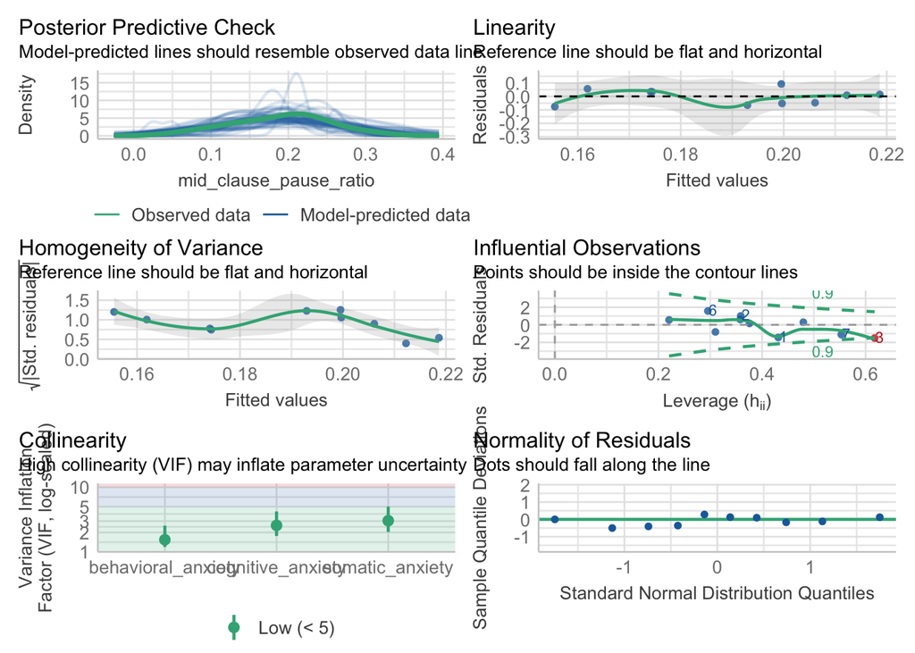

```r
check_model(model_mcpr)
```

The results suggested that the current model could be less reliable because the model could be affected by an outlier.

#### 4.2.2. ECPR ~ Speaking Anxiety

The following code block constructs a regression model between ECPR and speaking anxiety.

```r
model_ecpr <- lm(
  end_clause_pause_ratio ~ cognitive_anxiety + somatic_anxiety + behavioral_anxiety,
  df_uf_anxiety
)
```

The following code block shows the result.

```r
tab_model(model_ecpr, digits = 3)
```

|  | end_clause_pause_ratio |  |  |
| --- | --- | --- | --- |
| Predictors | Estimates | CI | p |
| (Intercept) | 0.093 | 0.066 – 0.121 | **<0.001** |
| cognitive anxiety | -0.003 | -0.007 – 0.001 | 0.081 |
| somatic anxiety | 0.001 | -0.002 – 0.004 | 0.458 |
| behavioral anxiety | -0.001 | -0.004 – 0.003 | 0.674 |
| Observations | 10 |  |  |
| R<sup>2</sup> / R<sup>2</sup> adjusted | 0.542 / 0.313 |  |  |

The result showed slightly significant relationship between cognitive anxiety and ECPR ($p=.081$). The slope was $-.003$ and suggested that ECPR decreased $.003$ when cognitive anxiety increased $1$.

To examine the reliability of the current model, the following code block conducts post-hoc analysis of regression assumptions.

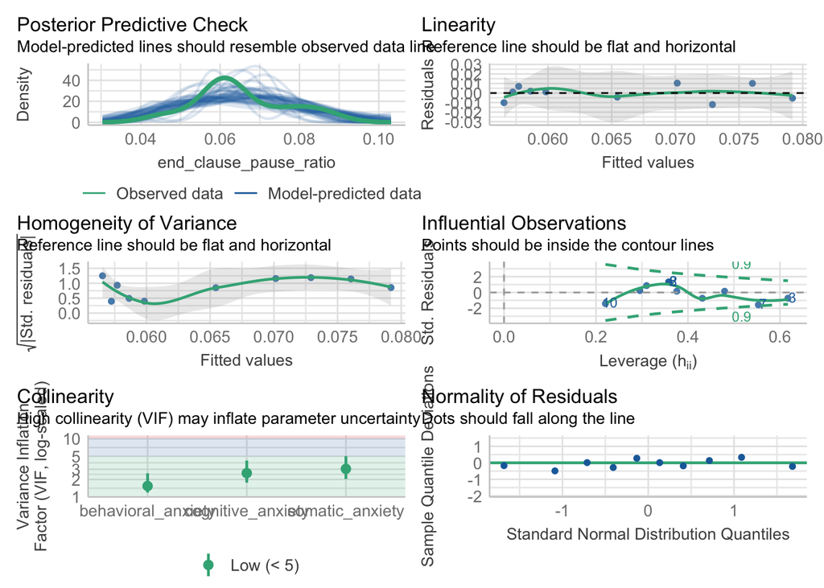

```r
check_model(model_ecpr)
```

The results suggested that the current model could be reliable.

#### 4.2.3. MCPD ~ Speaking Anxiety

The following code block constructs a regression model between MCPD and speaking anxiety.

```r
model_mcpd <- lm(
  mid_clause_p.dur ~ cognitive_anxiety + somatic_anxiety + behavioral_anxiety,
  df_uf_anxiety
)
```

The following code block shows the result.

```r
tab_model(model_mcpd, digits = 3)
```

|  | mid_clause_p.dur |  |  |
| --- | --- | --- | --- |
| Predictors | Estimates | CI | p |
| (Intercept) | 1.236 | 0.686 – 1.787 | **0.002** |
| cognitive anxiety | -0.014 | -0.088 – 0.060 | 0.655 |
| somatic anxiety | 0.026 | -0.040 – 0.092 | 0.375 |
| behavioral anxiety | -0.074 | -0.136 – -0.013 | **0.025** |
| Observations | 10 |  |  |
| R<sup>2</sup> / R<sup>2</sup> adjusted | 0.634 / 0.451 |  |  |

The result showed a significant link between behavioral anxiety and MCPD ($p=.025$). The slope was $-.074$, suggesting that MCPD became $.074$ shorter when behavioral anxiety score increased $1$.

To examine the reliability of the current model, the following code block conducts post-hoc analysis of regression assumptions.

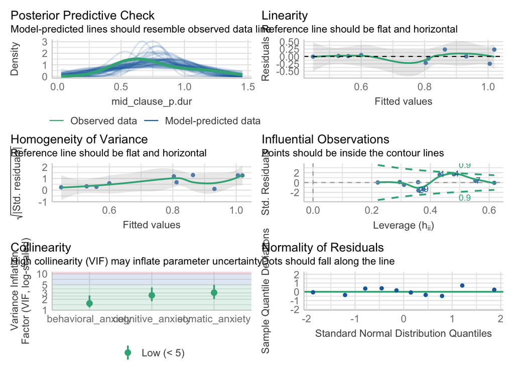

```r
check_model(model_mcpd)
```

The results suggested that the current model could be reliable.

#### 4.2.4. ECPD ~ Speaking Anxiety

```r
model_ecpd <- lm(
  end_clause_p.dur ~ cognitive_anxiety + somatic_anxiety + behavioral_anxiety,
  df_uf_anxiety
)
```

The following code block shows the result.

```r
tab_model(model_ecpd, digits = 3)
```

|  | end_clause_p.dur |  |  |
| --- | --- | --- | --- |
| Predictors | Estimates | CI | p |
| (Intercept) | 1.262 | 0.762 – 1.763 | **0.001** |
| cognitive anxiety | -0.005 | -0.072 – 0.062 | 0.872 |
| somatic anxiety | 0.017 | -0.043 – 0.077 | 0.511 |
| behavioral anxiety | -0.072 | -0.127 – -0.016 | **0.020** |
| Observations | 10 |  |  |
| R<sup>2</sup> / R<sup>2</sup> adjusted | 0.661 / 0.491 |  |  |

To examine the reliability of the current model, the following code block conducts post-hoc analysis of regression assumptions.

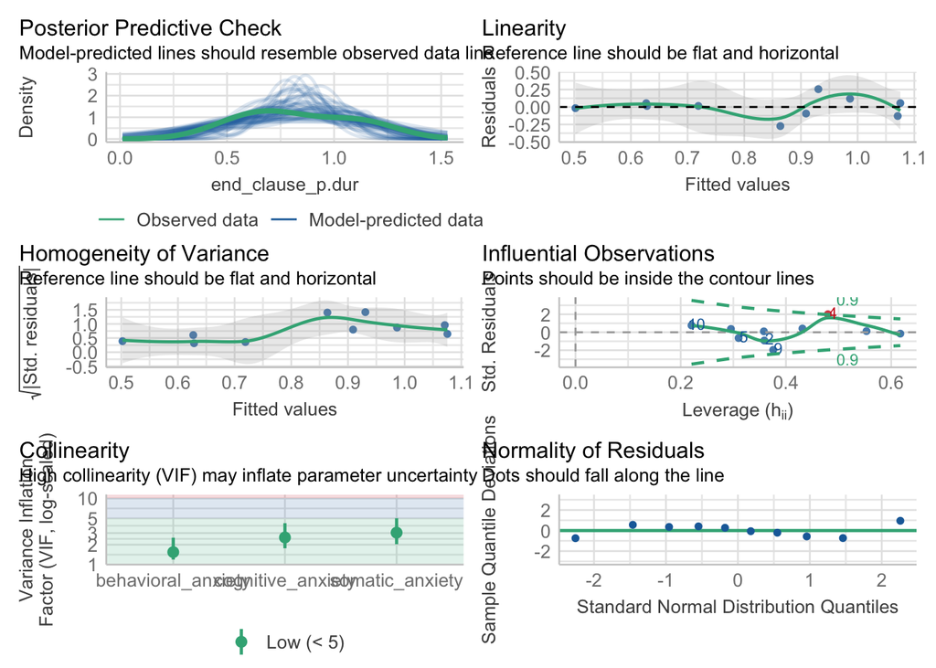

```r
check_model(model_ecpd)
```

### 4.3. RF ~ Speaking Anxiety

The following code block constructs a regression model between DR and speaking anxiety.

```r
model_dr <- lm(
  disfluency_ratio ~ cognitive_anxiety + somatic_anxiety + behavioral_anxiety,
  df_uf_anxiety
)
```

The following code block shows the result.

```r
tab_model(model_dr, digits = 3)
```

|  | disfluency_ratio |  |  |
| --- | --- | --- | --- |
| Predictors | Estimates | CI | p |
| (Intercept) | 0.038 | -0.106 – 0.182 | 0.541 |
| cognitive anxiety | 0.003 | -0.016 – 0.022 | 0.712 |
| somatic anxiety | -0.003 | -0.020 – 0.014 | 0.661 |
| behavioral anxiety | 0.003 | -0.013 – 0.019 | 0.631 |
| Observations | 10 |  |  |
| R<sup>2</sup> / R<sup>2</sup> adjusted | 0.066 / -0.401 |  |  |

The result did not show significant relationship between three anxiety scores and DR.

To examine the reliability of the current model, the following code block conducts post-hoc analysis of regression assumptions.

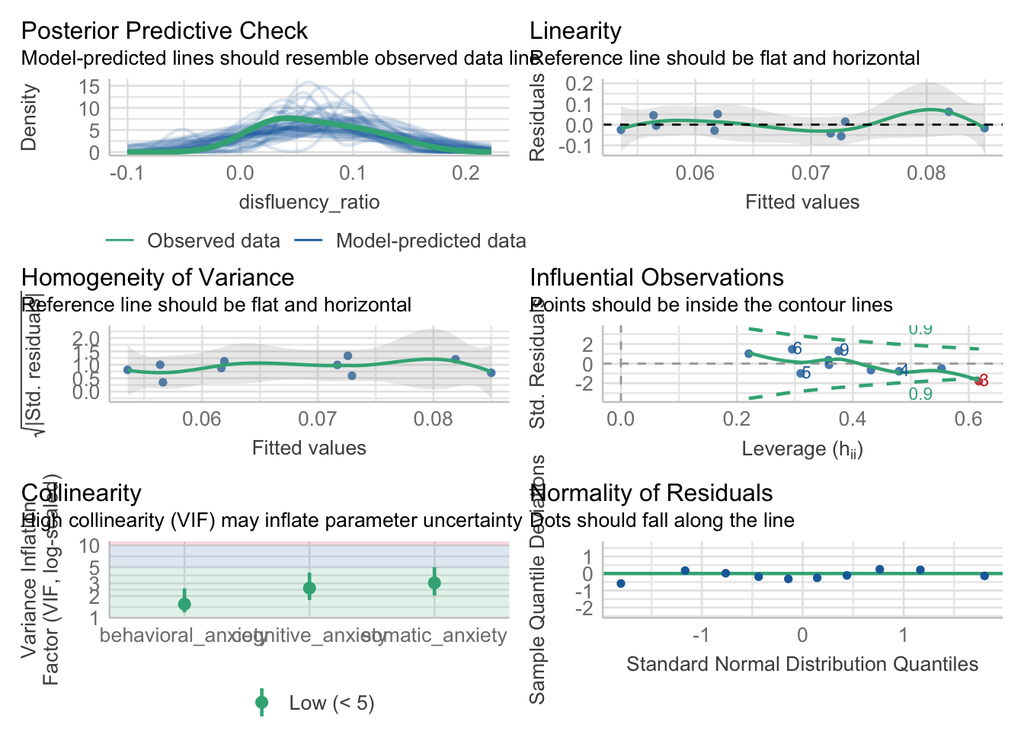

```r
check_model(model_dr)
```

The results suggested that the current model could be less reliable because the model could be affected by an outlier.

The following code block shows the summary of regression models.

```r
tab_model(
  model_ar,
  model_mcpr,
  model_ecpr,
  model_mcpd,
  model_ecpd,
  model_dr,
  dv.labels = c("AR", "MCPR", "ECPR", "MCPD", "ECPD", "DR"),
  pred.labels = c("(Intercept)", "CA", "SA", "BA"),
  digits = 3
)
```

|  | AR |  |  | MCPR |  |  | ECPR |  |  | MCPD |  |  | ECPD |  |  | DR |  |  |
| --- | --- | --- | --- | --- | --- | --- | --- | --- | --- | --- | --- | --- | --- | --- | --- | --- | --- | --- |
| Predictors | Estimates | CI | p | Estimates | CI | p | Estimates | CI | p | Estimates | CI | p | Estimates | CI | p | Estimates | CI | p |
| (Intercept) | 3.649 | 1.383 – 5.915 | **0.008** | 0.124 | -0.074 – 0.323 | 0.177 | 0.093 | 0.066 – 0.121 | **<0.001** | 1.236 | 0.686 – 1.787 | **0.002** | 1.262 | 0.762 – 1.763 | **0.001** | 0.038 | -0.106 – 0.182 | 0.541 |
| CA | -0.036 | -0.340 – 0.267 | 0.778 | 0.006 | -0.020 – 0.033 | 0.580 | -0.003 | -0.007 – 0.001 | 0.081 | -0.014 | -0.088 – 0.060 | 0.655 | -0.005 | -0.072 – 0.062 | 0.872 | 0.003 | -0.016 – 0.022 | 0.712 |
| SA | -0.006 | -0.276 – 0.265 | 0.962 | -0.000 | -0.024 – 0.024 | 0.999 | 0.001 | -0.002 – 0.004 | 0.458 | 0.026 | -0.040 – 0.092 | 0.375 | 0.017 | -0.043 – 0.077 | 0.511 | -0.003 | -0.020 – 0.014 | 0.661 |
| BA | 0.081 | -0.172 – 0.333 | 0.464 | -0.000 | -0.022 – 0.022 | 0.995 | -0.001 | -0.004 – 0.003 | 0.674 | -0.074 | -0.136 – -0.013 | **0.025** | -0.072 | -0.127 – -0.016 | **0.020** | 0.003 | -0.013 – 0.019 | 0.631 |
| Observations | 10 |  |  | 10 |  |  | 10 |  |  | 10 |  |  | 10 |  |  | 10 |  |  |
| R<sup>2</sup> / R<sup>2</sup> adjusted | 0.104 / -0.344 |  |  | 0.127 / -0.310 |  |  | 0.542 / 0.313 |  |  | 0.634 / 0.451 |  |  | 0.661 / 0.491 |  |  | 0.066 / -0.401 |  |  |